# Making a Histogram of South American Coffee Production

Sylvia de Boer

###Objective Here, I will use spatial data packages and summary data to better understand and manipulate coffee production data from 2016 and 2017. Finally, I will produce a histogram that shows us the distribution of large and small scales of coffee production in South America.

###Installing the Correct Libraries First, it’s important to make sure you have the correct packages downloaded. Do so by inputting the following code.

```r
library(sf)
library(raster)
library(dplyr)
library(stringr)
library(tidyr)
library(spData)
```

###Understanding our Dataset

First, we’re going to look at our dataset.

```r
coffee_data
```

```
## # A tibble: 47 x 3
##    name_long                coffee_production_2016 coffee_production_2017
##    <chr>                                     <int>                  <int>
##  1 Angola                                       NA                     NA
##  2 Bolivia                                       3                      4
##  3 Brazil                                     3277                   2786
##  4 Burundi                                      37                     38
##  5 Cameroon                                      8                      6
##  6 Central African Republic                     NA                     NA
##  7 Congo, Dem. Rep. of                           4                     12
##  8 Colombia                                   1330                   1169
##  9 Costa Rica                                   28                     32
## 10 Côte d'Ivoire                               114                    130
## # … with 37 more rows
```

Here we see names of countries and coffee production by year for 2016 and 2017, in thousands of 60 kg bags. So next, we’re going to join the “world” set and the “coffee” datasets, in order to mesh the data for country statistics and coffee production and create a master set of data:

```r
world_coffee = left_join(world, coffee_data)
```

Next, we’re going to calculate mean production per country for the year 2016:

```r
mean(coffee_data$coffee_production_2016, na.rm = TRUE)
```

```
## [1] 261.3421
```

```r
mean(coffee_data$coffee_production_2017, na.rm = TRUE)
```

```
## [1] 250.5278
```

And the median:

```r
median(coffee_data$coffee_production_2016, na.rm = TRUE)
```

```
## [1] 36.5
```

```r
median(coffee_data$coffee_production_2017, na.rm = TRUE)
```

```
## [1] 40
```

And minimums and maximums:

```r
min(coffee_data$coffee_production_2016, na.rm = TRUE)
```

```
## [1] 1
```

```r
min (coffee_data$coffee_production_2017, na.rm = TRUE)
```

```
## [1] 1
```

```r
max(coffee_data$coffee_production_2016, na.rm = TRUE)
```

```
## [1] 3277
```

```r
max(coffee_data$coffee_production_2017, na.rm = TRUE)
```

```
## [1] 2786
```

If we want to look at total coffee production over the two year period, it’s easy to mesh the 2016 and 2017 columns.

```r
world_coffee$total_coffee_production <- world_coffee$coffee_production_2016 + world_coffee$coffee_production_2017
```

Let’s say we decide to make an object for major producers, where total coffee production exceeds 700,000 bags for the two-yea rperiod:

```r
major_producers2 = world_coffee[world_coffee$total_coffee_production > 700, na.rm=TRUE]
```

We can also just work with South America, by filtering out those producers (and changing the name to SA_coffee_production as I did here, because it’s more accurate, since there are lots of countries in the database taht don’t produce coffee):

```r
southamerica = world_coffee %>% filter(continent == "South America")
southamerica_coffee_producers = world_coffee[southamerica, ]
```

```
## although coordinates are longitude/latitude, st_intersects assumes that they are planar
```

```r
SA_coffee_production <- southamerica_coffee_producers
```

Finally, we’re going to make a histogram of South American coffee production. To spice it up, we’ll make the borders dark green, the columns pale green, and we’ll give it breaks of 1000 on the x axis.

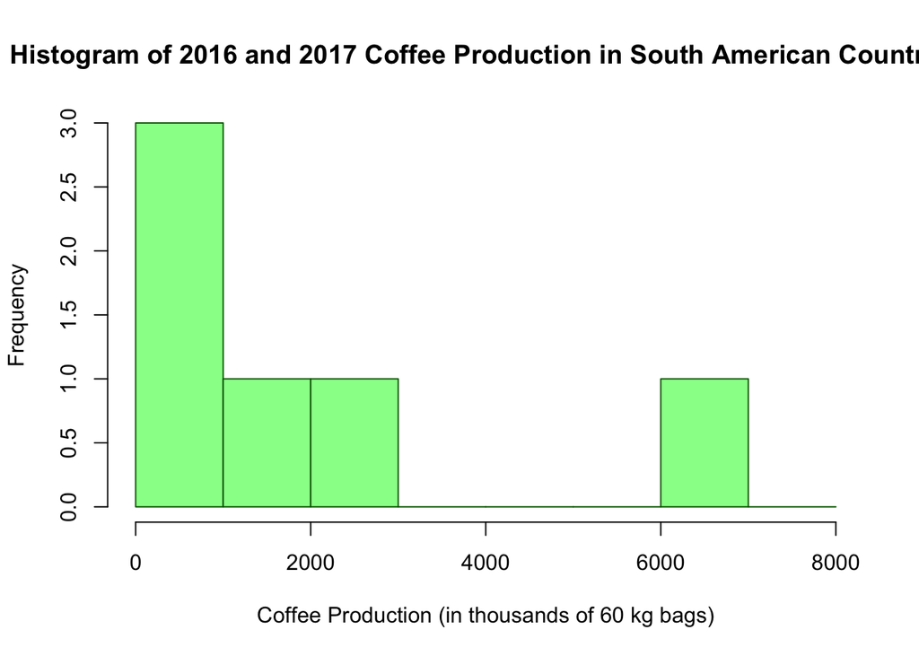

```r
hist(SA_coffee_production$total_coffee_production,
    main="Histogram of 2016 and 2017 Coffee Production in South American Countries",
    xlab="Coffee Production (in thousands of 60 kg bags)",
    border="darkgreen",
    col="palegreen",
    breaks=seq(0,8000,by=1000)
)
```